# PAC1 Anàlisi de dades òmiques

Arantxa Vázquez

2024-10-27

```r
knitr::opts_chunk$set(echo = TRUE, warning = FALSE, message = FALSE)
```

# 1. Introducción

En Bioinformática nos encontramos con distintos desafíos al querer analizar grandes conjuntos de datos complejos puesto que, para dar validez a ensayos clínicos, con frecuencia se requieren grandes muestras y eso conlleva una recogida de datos muy voluminosa. Para hacer frente a este reto se usan herramientas como Bioconductor el cual engloba miles de paquetes ya simplificados y enfocados a tratar con este tipo de datos clínicos. En esta actividad pondremos en práctica algunos de los principales paquetes y veremos como se resuelve una tarea bioinformática.

# 2. Objetivos

- Objetivo general: realizar un análisis de datos ómicos obtenidos del repositorio https://github.com/nutrimetabolomics/metaboData/ mediante R y los paquetes incluídos en las librerías de Bioconductor.
- Objetivos específicos:
1. Poner en práctica los conocimientos adquiridos sobre Bioconductor
2. Crear un contenedor tipo SummarizedExperiment para aprender más sobre su uso
3. Realizar un análisis exploratorio de los datos ómicos elegidos

# 3. Materiales y métodos

En primer lugar, instalamos algunos de los paquetes que podemos necesitar:

```r
if (!require(SummarizedExperiment)) BiocManager::install("SummarizedExperiment")
if (!require(PCAtools)) BiocManager::install("PCAtools")
if (!require(factoextra)) install.packages("factoextra", dep = TRUE)
if (!require(ggalt)) install.packages("ggalt", dep = TRUE)
```

Vamos a seleccionar un conjunto de datos del repositorio gitHub https://github.com/nutrimetabolomics/metaboData/. Hemos elegido el conjunto de datos de Cachexia porque es una patología que afecta a un gran porcentaje de pacientes oncológicos [1] y tiene un dataset muy popular donde se miden 63 metabolitos y se intentan correlacionar con la pérdida de masa muscular que es uno de los efectos más preocupantes de esta enfermedad.

A continuación importamos el dataset desde el repositorio.

```r
# Importamos librerías
library(readxl)
library(knitr)

# Importamos el dataset
file_path <- "/Users/varantxa/metaboData/Datasets/2024-Cachexia/human_cachexia.csv"
data <- read.csv(file_path)

# Imprimimos las primeras líneas para comprobar la correcta importación
kable(head(data))
```

| Patient.ID | Muscle.loss | X1.6.Anhydro.beta.D.glucose | X1.Methylnicotinamide | X2.Aminobutyrate | X2.Hydroxyisobutyrate | X2.Oxoglutarate | X3.Aminoisobutyrate | X3.Hydroxybutyrate | X3.Hydroxyisovalerate | X3.Indoxylsulfate | X4.Hydroxyphenylacetate | Acetate | Acetone | Adipate | Alanine | Asparagine | Betaine | Carnitine | Citrate | Creatine | Creatinine | Dimethylamine | Ethanolamine | Formate | Fucose | Fumarate | Glucose | Glutamine | Glycine | … |
| --- | --- | --- | --- | --- | --- | --- | --- | --- | --- | --- | --- | --- | --- | --- | --- | --- | --- | --- | --- | --- | --- | --- | --- | --- | --- | --- | --- | --- | --- | --- |
| PIF_178 | cachexic | 40.85 | 65.37 | 18.73 | 26.05 | 71.52 | 1480.30 | 56.83 | 10.07 | 566.80 | 120.30 | 126.47 | 9.49 | 38.09 | 314.19 | 159.17 | 109.95 | 265.07 | 3714.50 | 196.37 | 16481.60 | 632.70 | 645.48 | 441.42 | 336.97 | 7.69 | 395.44 | 871.31 | 2038.56 | … |
| PIF_087 | cachexic | 62.18 | 340.36 | 24.29 | 41.68 | 67.36 | 116.75 | 43.82 | 79.84 | 368.71 | 432.68 | 212.72 | 11.82 | 327.01 | 871.31 | 157.59 | 244.69 | 120.30 | 2617.57 | 212.72 | 15835.35 | 607.89 | 487.85 | 252.14 | 198.34 | 18.92 | 8690.62 | 601.85 | 1107.65 | … |
| PIF_090 | cachexic | 270.43 | 64.72 | 12.18 | 65.37 | 23.81 | 14.30 | 5.64 | 23.34 | 665.14 | 292.95 | 314.19 | 4.44 | 131.63 | 464.05 | 89.12 | 116.75 | 25.03 | 862.64 | 221.41 | 24587.66 | 735.10 | 407.48 | 249.64 | 186.79 | 7.10 | 1352.89 | 301.87 | 620.17 | … |
| NETL_005_V1 | cachexic | 154.47 | 52.98 | 172.43 | 74.44 | 1199.91 | 555.57 | 175.91 | 25.03 | 411.58 | 214.86 | 37.34 | 206.44 | 144.03 | 589.93 | 273.14 | 278.66 | 200.34 | 13629.61 | 85.63 | 20952.22 | 1064.22 | 820.57 | 468.72 | 407.48 | 96.54 | 862.64 | 1685.81 | 5064.45 | … |
| PIF_115 | cachexic | 22.20 | 73.70 | 15.64 | 83.93 | 33.12 | 29.67 | 76.71 | 69.41 | 165.67 | 97.51 | 407.48 | 44.26 | 15.03 | 1118.79 | 42.52 | 391.51 | 84.77 | 854.06 | 105.64 | 6768.26 | 242.26 | 365.04 | 114.43 | 26.05 | 19.69 | 6836.29 | 432.68 | 395.44 | … |
| PIF_110 | cachexic | 212.72 | 31.82 | 18.36 | 80.64 | 47.94 | 17.46 | 31.82 | 35.16 | 183.09 | 132.95 | 81.45 | 14.44 | 25.28 | 237.46 | 157.59 | 66.69 | 40.04 | 1958.63 | 200.34 | 15677.78 | 614.00 | 459.44 | 314.19 | 123.97 | 5.05 | 512.86 | 298.87 | 482.99 | … |

Los métodos utilizados son análisis bioinformáticos y bioestadísticos. Hemos utilizado la expresión de Summarized Experiment para poder trabajar con los conjuntos de datos con sus metadatos y poder seleccionar exactamente las variables que deseáramos sin perder información. A demás hemos realizado análisis estadísticos tales como mapas de calor, matrices de correlaciones y análisis de componentes principales para entender cómo se correlacionaban nuestras variables.

# 4. Resultados

En primer lugar hemos observado los datos originales para comprobar qué estructura seguían y hemos visto que es un conjunto de datos donde hay 77 observaciones y 63 variables medidas.

```r
# Observamos la estructura del dataset
str(data)
```

```
## 'data.frame':    77 obs. of  65 variables:
##  $ Patient.ID                 : chr  "PIF_178" "PIF_087" "PIF_090" "NETL_005_V1" ...
##  $ Muscle.loss                : chr  "cachexic" "cachexic" "cachexic" "cachexic" ...
##  $ X1.6.Anhydro.beta.D.glucose: num  40.9 62.2 270.4 154.5 22.2 ...
##  $ X1.Methylnicotinamide      : num  65.4 340.4 64.7 53 73.7 ...
##  $ X2.Aminobutyrate           : num  18.7 24.3 12.2 172.4 15.6 ...
##  $ X2.Hydroxyisobutyrate      : num  26.1 41.7 65.4 74.4 83.9 ...
##  $ X2.Oxoglutarate            : num  71.5 67.4 23.8 1199.9 33.1 ...
##  $ X3.Aminoisobutyrate        : num  1480.3 116.8 14.3 555.6 29.7 ...
##  $ X3.Hydroxybutyrate         : num  56.83 43.82 5.64 175.91 76.71 ...
##  $ X3.Hydroxyisovalerate      : num  10.1 79.8 23.3 25 69.4 ...
##  $ X3.Indoxylsulfate          : num  567 369 665 412 166 ...
##  $ X4.Hydroxyphenylacetate    : num  120.3 432.7 292.9 214.9 97.5 ...
##  $ Acetate                    : num  126.5 212.7 314.2 37.3 407.5 ...
##  $ Acetone                    : num  9.49 11.82 4.44 206.44 44.26 ...
```

[output cut: 51 more lines]

A continuación hemos llevado a cabo la extracción de todos los datos y metadatos en un contenedor SummarizedExperiment. Para poder hacer este paso hemos tenido que extraer la matriz de abundancias de las variables, luego adaptar las longitudes y posteriormente hemos podido crear el Dataframe con los metadatos para finalmente guardarlo en un contenedor.

```r
# Cargamos la biblioteca SummarizedExperiment
library(SummarizedExperiment)

# Extraemos la matriz de abundancias, omitiendo las primeras dos columnas (Patient.ID y Muscle.loss)
counts_matrix <- as.matrix(data[, -c(1, 2)])

# Asignamos los nombres de fila utilizando el identificador de paciente
rownames(counts_matrix) <- data$Patient.ID

# Aseguramos que los nombres de fila sean únicos y válidos
rownames(counts_matrix) <- make.names(data$Patient.ID, unique = TRUE)

# Creamos un vector de condiciones que refleje el estado de Muscle.loss para las muestras usando la longitud de counts_matrix para asegurar que coinciden
conditions <- factor(data$Muscle.loss[1:ncol(counts_matrix)])

# Creamos el DataFrame de metadatos
colData <- DataFrame(sample = colnames(counts_matrix), condition = conditions)

# Verificamos la estructura de colData
str(colData)
```

```
## Formal class 'DFrame' [package "S4Vectors"] with 6 slots
##   ..@ rownames       : NULL
##   ..@ nrows          : int 63
##   ..@ elementType    : chr "ANY"
##   ..@ elementMetadata: NULL
##   ..@ metadata       : list()
##   ..@ listData       :List of 2
##   .. ..$ sample   : chr [1:63] "X1.6.Anhydro.beta.D.glucose" "X1.Methylnicotinamide" "X2.Aminobutyrate" "X2.Hydroxyisobutyrate" ...
##   .. ..$ condition: Factor w/ 2 levels "cachexic","control": 1 1 1 1 1 1 1 1 1 1 ...
```

```r
# Creamos el objeto SummarizedExperiment con los datos de abundancias y los metadatos
se <- SummarizedExperiment(assays = list(counts = counts_matrix), colData = colData)

# Imprimimos el resumen del objeto para comprobar que se haya creado correctamente
print(se)
```

```
## class: SummarizedExperiment
## dim: 77 63
## metadata(0):
## assays(1): counts
## rownames(77): PIF_178 PIF_087 ... NETL_003_V1 NETL_003_V2
## rowData names(0):
## colnames(63): X1.6.Anhydro.beta.D.glucose X1.Methylnicotinamide ...
##   pi.Methylhistidine tau.Methylhistidine
## colData names(2): sample condition
```

Una vez obtenido nuestro objeto ‘se’ procedemos al análisis exploratorio:

1. Observamos las dimensiones del objeto y los nombres de columnas y filas

```r
# Inspeccionamos las dimensiones
dim(se)
```

```
## [1] 77 63
```

```r
# Observamos los nombres de las filas (muestras) y columnas (metabolitos)
rownames(se)
```

```
##  [1] "PIF_178"      "PIF_087"      "PIF_090"      "NETL_005_V1"  "PIF_115"
##  [6] "PIF_110"      "NETL_019_V1"  "NETCR_014_V1" "NETCR_014_V2" "PIF_154"
## [11] "NETL_022_V1"  "NETL_022_V2"  "NETL_008_V1"  "PIF_146"      "PIF_119"
## [16] "PIF_099"      "PIF_162"      "PIF_160"      "PIF_113"      "PIF_143"
## [21] "NETCR_007_V1" "NETCR_007_V2" "PIF_137"      "PIF_100"      "NETL_004_V1"
## [26] "PIF_094"      "PIF_132"      "PIF_163"      "NETCR_003_V1" "NETL_028_V1"
## [31] "NETL_028_V2"  "NETCR_013_V1" "NETL_020_V1"  "NETL_020_V2"  "PIF_192"
## [36] "NETCR_012_V1" "NETCR_012_V2" "PIF_089"      "NETCR_002_V1" "PIF_179"
## [41] "PIF_114"      "NETCR_006_V1" "PIF_141"      "NETCR_025_V1" "NETCR_025_V2"
## [46] "NETCR_016_V1" "PIF_116"      "PIF_191"      "PIF_164"      "NETL_013_V1"
## [51] "PIF_188"      "PIF_195"      "NETCR_015_V1" "PIF_102"      "NETL_010_V1"
## [56] "NETL_010_V2"  "NETL_001_V1"  "NETCR_015_V2" "NETCR_005_V1" "PIF_111"
## [61] "PIF_171"      "NETCR_008_V1" "NETCR_008_V2" "NETL_017_V1"  "NETL_017_V2"
## [66] "NETL_002_V1"  "NETL_002_V2"  "PIF_190"      "NETCR_009_V1" "NETCR_009_V2"
## [71] "NETL_007_V1"  "PIF_112"      "NETCR_019_V2" "NETL_012_V1"  "NETL_012_V2"
## [76] "NETL_003_V1"  "NETL_003_V2"
```

```r
colnames(se)
```

```
##  [1] "X1.6.Anhydro.beta.D.glucose" "X1.Methylnicotinamide"
##  [3] "X2.Aminobutyrate"            "X2.Hydroxyisobutyrate"
##  [5] "X2.Oxoglutarate"             "X3.Aminoisobutyrate"
##  [7] "X3.Hydroxybutyrate"          "X3.Hydroxyisovalerate"
##  [9] "X3.Indoxylsulfate"           "X4.Hydroxyphenylacetate"
## [11] "Acetate"                     "Acetone"
## [13] "Adipate"                     "Alanine"
## [15] "Asparagine"                  "Betaine"
## [17] "Carnitine"                   "Citrate"
## [19] "Creatine"                    "Creatinine"
## [21] "Dimethylamine"               "Ethanolamine"
## [23] "Formate"                     "Fucose"
## [25] "Fumarate"                    "Glucose"
## [27] "Glutamine"                   "Glycine"
## [29] "Glycolate"                   "Guanidoacetate"
```

[output cut: 17 more lines]

2. REalizamos un resumen estadístico para tener una visión general de los datos

```r
# Resumen estadístico de los datos
summary(assay(se))
```

```
##  X1.6.Anhydro.beta.D.glucose X1.Methylnicotinamide X2.Aminobutyrate
##  Min.   :  4.71              Min.   :   6.42       Min.   :  1.28
##  1st Qu.: 28.79              1st Qu.:  15.80       1st Qu.:  5.26
##  Median : 45.60              Median :  36.60       Median : 10.49
##  Mean   :105.63              Mean   :  71.57       Mean   : 18.16
##  3rd Qu.:141.17              3rd Qu.:  73.70       3rd Qu.: 19.49
##  Max.   :685.40              Max.   :1032.77       Max.   :172.43
##  X2.Hydroxyisobutyrate X2.Oxoglutarate   X3.Aminoisobutyrate X3.Hydroxybutyrate
##  Min.   : 4.85         Min.   :   5.53   Min.   :   2.61     Min.   :  1.70
##  1st Qu.:15.80         1st Qu.:  22.42   1st Qu.:  11.70     1st Qu.:  5.99
##  Median :32.46         Median :  55.15   Median :  22.65     Median : 11.70
##  Mean   :37.25         Mean   : 145.09   Mean   :  76.76     Mean   : 21.72
##  3rd Qu.:54.60         3rd Qu.:  92.76   3rd Qu.:  56.26     3rd Qu.: 29.96
##  Max.   :93.69         Max.   :2465.13   Max.   :1480.30     Max.   :175.91
##  X3.Hydroxyisovalerate X3.Indoxylsulfate X4.Hydroxyphenylacetate
##  Min.   :  0.92        Min.   :  27.66   Min.   : 15.49
##  1st Qu.:  5.26        1st Qu.:  82.27   1st Qu.: 41.68
##  Median : 12.55        Median : 144.03   Median : 70.11
##  Mean   : 21.65        Mean   : 218.88   Mean   :112.02
##  3rd Qu.: 30.27        3rd Qu.: 333.62   3rd Qu.:145.47
##  Max.   :164.02        Max.   :1043.15   Max.   :796.32
##     Acetate          Acetone          Adipate          Alanine
##  Min.   :  3.49   Min.   :  2.29   Min.   :  1.55   Min.   :  16.78
##  1st Qu.: 16.28   1st Qu.:  4.95   1st Qu.:  6.11   1st Qu.:  78.26
##  Median : 39.65   Median :  7.10   Median : 10.18   Median : 194.42
##  Mean   : 66.14   Mean   : 11.43   Mean   : 24.76   Mean   : 273.56
##  3rd Qu.: 86.49   3rd Qu.: 10.49   3rd Qu.: 19.11   3rd Qu.: 399.41
##  Max.   :411.58   Max.   :206.44   Max.   :327.01   Max.   :1312.91
##    Asparagine        Betaine         Carnitine         Citrate
##  Min.   :  6.69   Min.   :  2.29   Min.   :  2.18   Min.   :   59.74
##  1st Qu.: 20.49   1st Qu.: 28.79   1st Qu.: 14.44   1st Qu.:  788.40
##  Median : 42.10   Median : 64.72   Median : 23.81   Median : 1790.05
##  Mean   : 62.28   Mean   : 90.32   Mean   : 52.09   Mean   : 2235.35
##  3rd Qu.: 89.12   3rd Qu.:127.74   3rd Qu.: 60.95   3rd Qu.: 3071.74
##  Max.   :273.14   Max.   :391.51   Max.   :487.85   Max.   :13629.61
##     Creatine         Creatinine    Dimethylamine      Ethanolamine
##  Min.   :   2.75   Min.   : 1002   Min.   :  41.26   Min.   :  16.12
##  1st Qu.:  17.64   1st Qu.: 3498   1st Qu.: 142.59   1st Qu.:  86.49
##  Median :  44.26   Median : 7631   Median : 304.90   Median : 204.38
##  Mean   : 126.83   Mean   : 8734   Mean   : 358.17   Mean   : 276.26
```

[output cut: 64 more lines]

```
##  Max.   :539.15   Max.   :179.47   Max.   :160.77   Max.   :2164.62
##  cis.Aconitate      myo.Inositol    trans.Aconitate  pi.Methylhistidine
##  Min.   :  12.94   Min.   : 11.59   Min.   :  4.90   Min.   :  11.36
##  1st Qu.:  36.23   1st Qu.: 30.27   1st Qu.: 12.43   1st Qu.:  67.36
##  Median : 129.02   Median : 78.26   Median : 26.84   Median : 162.39
##  Mean   : 204.22   Mean   :135.40   Mean   : 40.63   Mean   : 370.29
##  3rd Qu.: 254.68   3rd Qu.:167.34   3rd Qu.: 57.40   3rd Qu.: 387.61
##  Max.   :1863.11   Max.   :854.06   Max.   :217.02   Max.   :2697.28
##  tau.Methylhistidine
##  Min.   :  8.00
##  1st Qu.: 27.39
##  Median : 68.72
##  Mean   : 89.69
##  3rd Qu.:130.32
##  Max.   :317.35
```

3. Observamos la estructura de las condiciones y las muestras

```r
# Ver la estructura
str(colData(se))
```

```
## Formal class 'DFrame' [package "S4Vectors"] with 6 slots
##   ..@ rownames       : chr [1:63] "X1.6.Anhydro.beta.D.glucose" "X1.Methylnicotinamide" "X2.Aminobutyrate" "X2.Hydroxyisobutyrate" ...
##   ..@ nrows          : int 63
##   ..@ elementType    : chr "ANY"
##   ..@ elementMetadata: NULL
##   ..@ metadata       : list()
##   ..@ listData       :List of 2
##   .. ..$ sample   : chr [1:63] "X1.6.Anhydro.beta.D.glucose" "X1.Methylnicotinamide" "X2.Aminobutyrate" "X2.Hydroxyisobutyrate" ...
##   .. ..$ condition: Factor w/ 2 levels "cachexic","control": 1 1 1 1 1 1 1 1 1 1 ...
```

4. Realizamos una tabla de frecuencias de las condiciones

```r
# Tabla de frecuencias para las condiciones
table(colData(se)$condition)
```

```
##
## cachexic  control
##       47       16
```

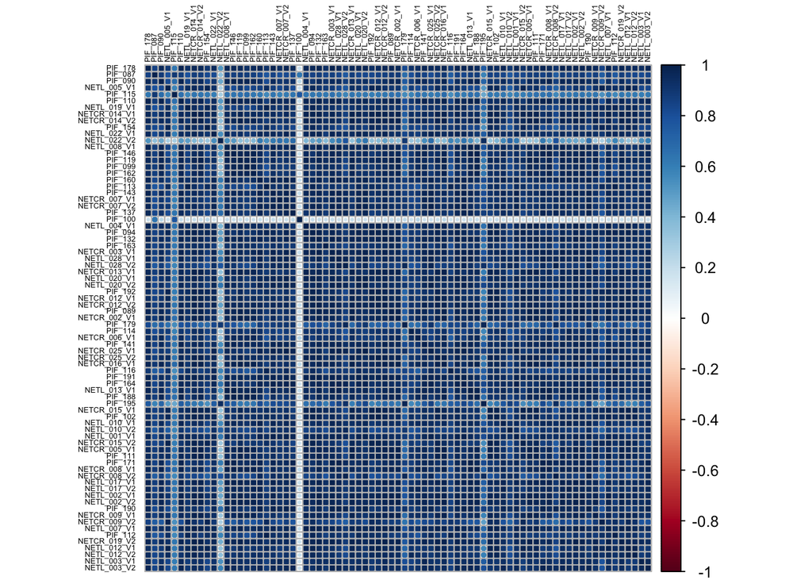

```r
# Importamos la librería
library(corrplot)

# Creamos e imprimimos la matriz
cor_matrix <- cor(t(assay(se)), use = "complete.obs")
corrplot(cor_matrix, method = "circle", tl.col = "black", tl.cex = 0.4)  # Ajustar el tamaño de la fuente
```

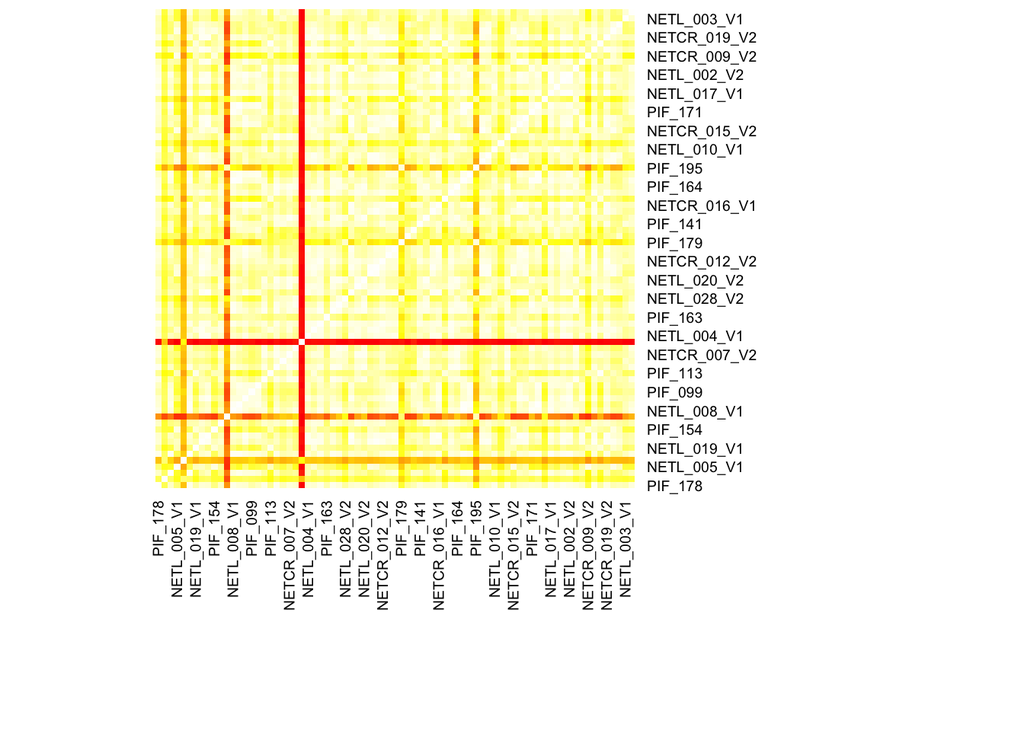

```r
# Importamos librerías
library(corrplot)

# Creamos el mapa de calor
cor_matrix <- cor(t(assay(se)), use = "complete.obs")
heatmap(cor_matrix, Rowv = NA, Colv = NA, scale = "none", col = heat.colors(256), margins = c(10, 10))
```

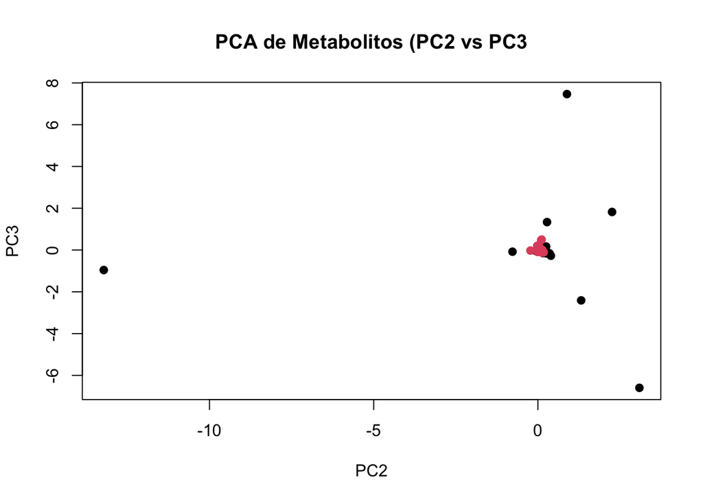

```r
# Estandarizaoms los datos
standardized_data <- scale(t(assay(se)))

# Realizamos el PCA
pca_result <- prcomp(standardized_data)

# Imprimimos el gráfico del PCA
plot(pca_result$x[, c(2, 3)], col = as.factor(colData(se)$condition),
     pch = 19, xlab = "PC2", ylab = "PC3", main = "PCA de Metabolitos (PC2 vs PC3")
```

# 5. Discusión

En este trabajo hemos practivado el uso de Bioconductor y contenedores para poder agrupar una gran cantidad de datos y hemos visto lo fácil que resulta el manejo de los datos ómicos con estas herramientas.

# 6. Referencias

- Instituto Nacional del Cáncer. Caquexia [Internet]. [Actualizado el 20 de marzo de 2020; consultado el 6 de noviembre de 2024]. Disponible en: https://www.cancer.gov/espanol/cancer/tratamiento/investigacion/caquexia.

# 7. Repositorio gitHub

https://github.com/varantxa/Vazquez-Albacete-Arantxa-PEC1.git

```r
# Guardamos el objeto SummarizedExperiment en un archivo .Rda
save(se, file = "se_metabolitos.Rda")
```